# IE423 PROJECT PART 2

Melih Kocakaplan 2019402210

Demet Şeker 2019402141

Simay Kartal 2019402027

#### Discussion

```python
import pandas as pd
from datetime import datetime
import matplotlib.pyplot as plt
import numpy as np
import seaborn as sns
from scipy.stats import pearsonr, linregress
from statsmodels.tsa.arima.model import ARIMA
from statsmodels.graphics.tsaplots import plot_acf, plot_pacf
```

```python
# Load the BIST30 Stock Data, adjust the timestamp column and turn it into an easily revisible dataframe.
dosya_yolları = [

    "C:/Users/meeli/Downloads/20180101_20180401_bist30.csv",
    "C:/Users/meeli/Downloads/20180402_20180701_bist30.csv",
    "C:/Users/meeli/Downloads/20180702_20180930_bist30.csv",
    "C:/Users/meeli/Downloads/20181001_20181230_bist30.csv",
    "C:/Users/meeli/Downloads/20181231_20190331_bist30.csv",
    "C:/Users/meeli/Downloads/20190401_20190630_bist30.csv",
    "C:/Users/meeli/Downloads/20190701_20190929_bist30.csv",
    "C:/Users/meeli/Downloads/20190930_20191229_bist30.csv",
    "C:/Users/meeli/Downloads/20191230_20200329_bist30.csv",
    "C:/Users/meeli/Downloads/20200330_20200628_bist30.csv",
    "C:/Users/meeli/Downloads/20200629_20200927_bist30.csv",
    "C:/Users/meeli/Downloads/20200928_20201227_bist30.csv",
    "C:/Users/meeli/Downloads/20201228_20210328_bist30.csv",
    "C:/Users/meeli/Downloads/20210329_20210627_bist30.csv",
    "C:/Users/meeli/Downloads/20210628_20210926_bist30.csv",
    "C:/Users/meeli/Downloads/20210927_20211226_bist30.csv",
    "C:/Users/meeli/Downloads/20211227_20220327_bist30.csv",
    "C:/Users/meeli/Downloads/20220328_20220626_bist30.csv",
    "C:/Users/meeli/Downloads/20220627_20220925_bist30.csv",
    "C:/Users/meeli/Downloads/20220926_20221225_bist30.csv",
    "C:/Users/meeli/Downloads/20221226_20230326_bist30.csv",
    "C:/Users/meeli/Downloads/20230327_20230625_bist30.csv",
    "C:/Users/meeli/Downloads/20230626_20230924_bist30.csv",
    "C:/Users/meeli/Downloads/20230925_20231224_bist30.csv"
]

df_list = []
for dosya_yolu in dosya_yolları:
    df = pd.read_csv(dosya_yolu)
    df_list.append(df)

df_final = pd.concat(df_list, ignore_index = True)

def date_updater(date):
    temp = datetime.strptime(date, "%Y-%m-%d %H:%M:%S%z")
    return datetime.strptime(temp.strftime("%Y-%m-%d %H:%M:%S"), "%Y-%m-%d %H:%M:%S")

df_final["timestamp"] = df_final["timestamp"].apply(date_updater)

df_lists = []
l = df_final["short_name"].unique()
k = len(l)
for i in range(0,k):
    df_temp = df_final[df_final["short_name"]==l[i]][["timestamp", "price"]]
    df_temp.rename(columns={"timestamp": "date", "price": l[i]}, inplace=True)
    df_lists.append(df_temp)
    print(l[i], len(df_temp), df_temp[l[i]].isna().sum())
```

```
THYAO 14642 0
AKBNK 14642 0
ARCLK 14642 0
ASELS 14532 0
BIMAS 14642 0
DOHOL 14642 0
EKGYO 14642 0
EREGL 14642 0
FROTO 14641 0
GUBRF 14633 0
GARAN 14642 0
KRDMD 14642 0
KCHOL 14642 0
KOZAL 14642 0
KOZAA 14642 0
PGSUS 14637 0
PETKM 14642 0
SAHOL 14641 0
SASA 14640 0
SISE 14642 0
TAVHL 14642 0
TKFEN 14642 0
TUPRS 14642 0
TTKOM 14642 0
TCELL 14642 0
HALKB 14642 0
ISCTR 14642 0
VAKBN 14642 0
VESTL 14642 0
YKBNK 14642 0
```

```python
# drop #ASELS stock as it has relatively smaller number of instances than other stocks have.
df_lists.pop(3)
stock_data = pd.DataFrame()
for i in range(0,k-1):
    if i == 0:
        stock_data = df_lists[i]
    else:
        stock_data = stock_data.merge(df_lists[i], on = "date")
```

```python
stock_data # we obtained a better structured dataframe to operate on.
```

|  | date | THYAO | AKBNK | ARCLK | BIMAS | DOHOL | EKGYO | EREGL | FROTO | GUBRF | ... | TAVHL | TKFEN | TUPRS | TTKOM | TCELL | HALKB | ISCTR | VAKBN | VESTL | YKBNK |
| --- | --- | --- | --- | --- | --- | --- | --- | --- | --- | --- | --- | --- | --- | --- | --- | --- | --- | --- | --- | --- | --- |
| 0 | 2018-01-02 09:00:00 | 15.79 | 6.9475 | 18.4146 | 31.8609 | 0.7028 | 2.3141 | 6.0021 | 42.0959 | 4.20 | ... | 18.4807 | 12.7352 | 12.2392 | 4.9603 | 12.1212 | 10.5358 | 2.6331 | 6.6842 | 5.9926 | 2.4490 |
| 1 | 2018-01-02 10:00:00 | 16.01 | 7.0602 | 18.4999 | 32.2076 | 0.7110 | 2.3387 | 6.0199 | 42.3053 | 4.19 | ... | 18.6442 | 12.7952 | 12.3095 | 5.0726 | 12.1604 | 10.8577 | 2.6444 | 6.7927 | 6.1659 | 2.4659 |
| 2 | 2018-01-02 11:00:00 | 16.05 | 7.0954 | 18.3804 | 32.0850 | 0.7110 | 2.3306 | 5.9962 | 42.6195 | 4.22 | ... | 18.5788 | 12.6978 | 12.2894 | 5.0726 | 12.0586 | 10.8382 | 2.6444 | 6.8715 | 6.4809 | 2.4828 |
| 3 | 2018-01-02 12:00:00 | 16.05 | 7.0814 | 18.3633 | 31.9017 | 0.7110 | 2.3387 | 5.9962 | 42.7939 | 4.25 | ... | 18.6278 | 12.5855 | 12.2995 | 5.0565 | 12.0509 | 10.7406 | 2.6369 | 6.8715 | 6.5202 | 2.4828 |
| 4 | 2018-01-02 13:00:00 | 16.06 | 7.1024 | 18.3633 | 32.0443 | 0.7189 | 2.3387 | 6.0080 | 42.6544 | 4.26 | ... | 18.6278 | 12.5855 | 12.3195 | 5.0565 | 12.1057 | 10.7601 | 2.6369 | 6.8814 | 6.5202 | 2.4828 |
| ... | ... | ... | ... | ... | ... | ... | ... | ... | ... | ... | ... | ... | ... | ... | ... | ... | ... | ... | ... | ... | ... |
| 14619 | 2023-11-21 09:00:00 | 256.00 | 30.6800 | 145.0000 | 308.0000 | 13.6400 | 7.6800 | 39.8600 | 845.0000 | 377.50 | ... | 122.9000 | 44.2400 | 154.1000 | 22.3000 | 57.7000 | 13.2500 | 20.9800 | 15.2000 | 61.7500 | 17.1600 |
| 14620 | 2023-11-21 10:00:00 | 255.00 | 30.4800 | 143.8000 | 306.2500 | 13.6000 | 7.6300 | 40.9400 | 846.0000 | 377.50 | ... | 123.0000 | 44.8400 | 154.3000 | 22.3200 | 57.9500 | 13.2100 | 20.8600 | 15.1900 | 61.4500 | 17.0700 |
| 14621 | 2023-11-21 11:00:00 | 257.75 | 30.4800 | 143.3000 | 304.5000 | 13.5600 | 7.5900 | 40.9200 | 843.0000 | 372.50 | ... | 122.9000 | 45.2000 | 154.2000 | 22.0200 | 57.4000 | 13.1600 | 20.7800 | 15.1600 | 60.6500 | 17.0400 |
| 14622 | 2023-11-21 12:00:00 | 258.25 | 30.5000 | 143.5000 | 306.0000 | 13.5300 | 7.5900 | 40.9200 | 840.5000 | 372.75 | ... | 123.2000 | 44.7400 | 154.8000 | 22.0600 | 57.4500 | 13.1500 | 20.7800 | 15.1400 | 60.5500 | 17.0500 |
| 14623 | 2023-11-21 13:00:00 | 258.25 | 30.4600 | 143.5000 | 305.7500 | 13.4800 | 7.5800 | 40.8400 | 841.5000 | 372.50 | ... | 122.8000 | 44.6800 | 153.9000 | 21.9000 | 57.3500 | 13.0700 | 20.7400 | 15.0800 | 60.4000 | 16.9900 |

14624 rows × 30 columns

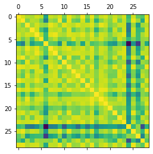

```python
# first trial to select highly correlated stocks
correlation_matrix = stock_data.corr()
plt.matshow(correlation_matrix)
```

```python
# as the above visualization do not work very well, let's examine the correlation matrix itself first
correlation_matrix
```

|  | THYAO | AKBNK | ARCLK | BIMAS | DOHOL | EKGYO | EREGL | FROTO | GUBRF | GARAN | ... | TAVHL | TKFEN | TUPRS | TTKOM | TCELL | HALKB | ISCTR | VAKBN | VESTL | YKBNK |
| --- | --- | --- | --- | --- | --- | --- | --- | --- | --- | --- | --- | --- | --- | --- | --- | --- | --- | --- | --- | --- | --- |
| THYAO | 1.000000 | 0.978107 | 0.955641 | 0.951459 | 0.971705 | 0.960405 | 0.835001 | 0.968241 | 0.958748 | 0.977263 | ... | 0.976164 | 0.942207 | 0.968867 | 0.946489 | 0.973725 | 0.875058 | 0.970836 | 0.907308 | 0.895587 | 0.983344 |
| AKBNK | 0.978107 | 1.000000 | 0.927602 | 0.956536 | 0.952216 | 0.917121 | 0.782726 | 0.941905 | 0.928511 | 0.992622 | ... | 0.956868 | 0.927865 | 0.978730 | 0.915047 | 0.964035 | 0.892516 | 0.987427 | 0.945468 | 0.849809 | 0.985892 |
| ARCLK | 0.955641 | 0.927602 | 1.000000 | 0.945021 | 0.973362 | 0.948524 | 0.939424 | 0.985567 | 0.969488 | 0.938222 | ... | 0.970218 | 0.921722 | 0.942306 | 0.966676 | 0.966917 | 0.774303 | 0.941548 | 0.828730 | 0.946964 | 0.957585 |
| BIMAS | 0.951459 | 0.956536 | 0.945021 | 1.000000 | 0.969882 | 0.889957 | 0.835026 | 0.963759 | 0.954979 | 0.967795 | ... | 0.946432 | 0.890452 | 0.968121 | 0.915249 | 0.971461 | 0.766786 | 0.969062 | 0.872099 | 0.889837 | 0.970438 |
| DOHOL | 0.971705 | 0.952216 | 0.973362 | 0.969882 | 1.000000 | 0.958518 | 0.876785 | 0.980482 | 0.988036 | 0.956982 | ... | 0.964439 | 0.923939 | 0.956989 | 0.969799 | 0.984013 | 0.805493 | 0.962535 | 0.878861 | 0.949756 | 0.973960 |
| EKGYO | 0.960405 | 0.917121 | 0.948524 | 0.889957 | 0.958518 | 1.000000 | 0.873328 | 0.939205 | 0.959560 | 0.913302 | ... | 0.947839 | 0.927483 | 0.905469 | 0.971225 | 0.946541 | 0.871522 | 0.921672 | 0.879645 | 0.939535 | 0.943567 |
| EREGL | 0.835001 | 0.782726 | 0.939424 | 0.835026 | 0.876785 | 0.873328 | 1.000000 | 0.904710 | 0.896894 | 0.809525 | ... | 0.895116 | 0.834671 | 0.817689 | 0.909591 | 0.876338 | 0.614504 | 0.812541 | 0.679539 | 0.935630 | 0.847833 |
| FROTO | 0.968241 | 0.941905 | 0.985567 | 0.963759 | 0.980482 | 0.939205 | 0.904710 | 1.000000 | 0.975310 | 0.953496 | ... | 0.963218 | 0.905121 | 0.948132 | 0.951980 | 0.976632 | 0.777835 | 0.947968 | 0.833087 | 0.930510 | 0.965016 |
| GUBRF | 0.958748 | 0.928511 | 0.969488 | 0.954979 | 0.988036 | 0.959560 | 0.896894 | 0.975310 | 1.000000 | 0.934760 | ... | 0.955730 | 0.918397 | 0.939467 | 0.971514 | 0.977629 | 0.787489 | 0.944293 | 0.854688 | 0.963536 | 0.959529 |
| GARAN | 0.977263 | 0.992622 | 0.938222 | 0.967795 | 0.956982 | 0.913302 | 0.809525 | 0.953496 | 0.934760 | 1.000000 | ... | 0.963801 | 0.921120 | 0.975665 | 0.919192 | 0.970829 | 0.861613 | 0.983066 | 0.923382 | 0.860984 | 0.985538 |
| KRDMD | 0.921333 | 0.892328 | 0.981087 | 0.927157 | 0.949837 | 0.919507 | 0.959170 | 0.972204 | 0.956890 | 0.906287 | ... | 0.941798 | 0.883050 | 0.917084 | 0.943485 | 0.947481 | 0.727691 | 0.913876 | 0.785715 | 0.942664 | 0.930427 |
| KCHOL | 0.986617 | 0.982980 | 0.968218 | 0.978543 | 0.980147 | 0.935470 | 0.854098 | 0.982254 | 0.966735 | 0.985711 | ... | 0.973627 | 0.932168 | 0.983863 | 0.944646 | 0.985496 | 0.837354 | 0.983473 | 0.897552 | 0.900758 | 0.989405 |
| KOZAL | 0.957333 | 0.915760 | 0.958466 | 0.906260 | 0.972620 | 0.978016 | 0.874195 | 0.953070 | 0.972028 | 0.912135 | ... | 0.942892 | 0.924546 | 0.918731 | 0.976819 | 0.957037 | 0.823440 | 0.924519 | 0.848982 | 0.947683 | 0.937524 |
| KOZAA | 0.938982 | 0.904403 | 0.977773 | 0.934274 | 0.968334 | 0.947006 | 0.938483 | 0.963504 | 0.974523 | 0.916078 | ... | 0.957483 | 0.915771 | 0.918184 | 0.977420 | 0.965031 | 0.748652 | 0.920893 | 0.820446 | 0.964573 | 0.942221 |
| PGSUS | 0.993038 | 0.973118 | 0.962990 | 0.956857 | 0.982717 | 0.959944 | 0.844140 | 0.975380 | 0.967081 | 0.975068 | ... | 0.972315 | 0.934621 | 0.963585 | 0.958311 | 0.980761 | 0.847943 | 0.966665 | 0.895062 | 0.913986 | 0.978616 |
| PETKM | 0.923733 | 0.895420 | 0.967964 | 0.918737 | 0.949573 | 0.942475 | 0.956137 | 0.946950 | 0.960078 | 0.908709 | ... | 0.963603 | 0.922847 | 0.911165 | 0.958656 | 0.947812 | 0.763575 | 0.914588 | 0.835349 | 0.968616 | 0.940049 |
| SAHOL | 0.987892 | 0.968335 | 0.980288 | 0.958128 | 0.982083 | 0.969923 | 0.892678 | 0.979000 | 0.972914 | 0.972502 | ... | 0.986091 | 0.946201 | 0.965378 | 0.970755 | 0.982553 | 0.849262 | 0.971109 | 0.899117 | 0.931416 | 0.987688 |
| SASA | 0.924403 | 0.863703 | 0.934389 | 0.864411 | 0.922913 | 0.951769 | 0.903636 | 0.923366 | 0.929680 | 0.871449 | ... | 0.941246 | 0.901681 | 0.859681 | 0.936624 | 0.909301 | 0.775627 | 0.873077 | 0.804308 | 0.930337 | 0.916065 |
| SISE | 0.966305 | 0.927993 | 0.985292 | 0.931752 | 0.971395 | 0.972951 | 0.925661 | 0.970734 | 0.968527 | 0.934150 | ... | 0.979017 | 0.942552 | 0.938396 | 0.970855 | 0.960598 | 0.813358 | 0.943312 | 0.854330 | 0.949327 | 0.963000 |
| TAVHL | 0.976164 | 0.956868 | 0.970218 | 0.946432 | 0.964439 | 0.947839 | 0.895116 | 0.963218 | 0.955730 | 0.963801 | ... | 1.000000 | 0.962565 | 0.957926 | 0.952455 | 0.963515 | 0.823889 | 0.959143 | 0.882726 | 0.924442 | 0.977932 |
| TKFEN | 0.942207 | 0.927865 | 0.921722 | 0.890452 | 0.923939 | 0.927483 | 0.834671 | 0.905121 | 0.918397 | 0.921120 | ... | 0.962565 | 1.000000 | 0.927709 | 0.920974 | 0.926235 | 0.836819 | 0.930026 | 0.869568 | 0.889204 | 0.939799 |
| TUPRS | 0.968867 | 0.978730 | 0.942306 | 0.968121 | 0.956989 | 0.905469 | 0.817689 | 0.948132 | 0.939467 | 0.975665 | ... | 0.957926 | 0.927709 | 1.000000 | 0.915325 | 0.965682 | 0.836270 | 0.986125 | 0.905714 | 0.865633 | 0.975517 |
| TTKOM | 0.946489 | 0.915047 | 0.966676 | 0.915249 | 0.969799 | 0.971225 | 0.909591 | 0.951980 | 0.971514 | 0.919192 | ... | 0.952455 | 0.920974 | 0.915325 | 1.000000 | 0.968231 | 0.801634 | 0.924510 | 0.862315 | 0.963253 | 0.945435 |
| TCELL | 0.973725 | 0.964035 | 0.966917 | 0.971461 | 0.984013 | 0.946541 | 0.876338 | 0.976632 | 0.977629 | 0.970829 | ... | 0.963515 | 0.926235 | 0.965682 | 0.968231 | 1.000000 | 0.817854 | 0.964972 | 0.887413 | 0.930930 | 0.976026 |
| HALKB | 0.875058 | 0.892516 | 0.774303 | 0.766786 | 0.805493 | 0.871522 | 0.614504 | 0.777835 | 0.787489 | 0.861613 | ... | 0.823889 | 0.836819 | 0.836270 | 0.801634 | 0.817854 | 1.000000 | 0.872717 | 0.938111 | 0.706704 | 0.866801 |
| ISCTR | 0.970836 | 0.987427 | 0.941548 | 0.969062 | 0.962535 | 0.921672 | 0.812541 | 0.947968 | 0.944293 | 0.983066 | ... | 0.959143 | 0.930026 | 0.986125 | 0.924510 | 0.964972 | 0.872717 | 1.000000 | 0.934400 | 0.873135 | 0.988703 |
| VAKBN | 0.907308 | 0.945468 | 0.828730 | 0.872099 | 0.878861 | 0.879645 | 0.679539 | 0.833087 | 0.854688 | 0.923382 | ... | 0.882726 | 0.869568 | 0.905714 | 0.862315 | 0.887413 | 0.938111 | 0.934400 | 1.000000 | 0.788332 | 0.930962 |
| VESTL | 0.895587 | 0.849809 | 0.946964 | 0.889837 | 0.949756 | 0.939535 | 0.935630 | 0.930510 | 0.963536 | 0.860984 | ... | 0.924442 | 0.889204 | 0.865633 | 0.963253 | 0.930930 | 0.706704 | 0.873135 | 0.788332 | 1.000000 | 0.902177 |
| YKBNK | 0.983344 | 0.985892 | 0.957585 | 0.970438 | 0.973960 | 0.943567 | 0.847833 | 0.965016 | 0.959529 | 0.985538 | ... | 0.977932 | 0.939799 | 0.975517 | 0.945435 | 0.976026 | 0.866801 | 0.988703 | 0.930962 | 0.902177 | 1.000000 |

29 rows × 29 columns

```python
# here is a better representation of the correlation matrix with darker red colors represent a higher correlation and
# the cells that converges to blue represent a lower correlation.
correlation_matrix.style.background_gradient(cmap='coolwarm')
```

|  | THYAO | AKBNK | ARCLK | BIMAS | DOHOL | EKGYO | EREGL | FROTO | GUBRF | GARAN | KRDMD | KCHOL | KOZAL | KOZAA | PGSUS | PETKM | SAHOL | SASA | SISE | TAVHL | TKFEN | TUPRS | TTKOM | TCELL | HALKB | ISCTR | VAKBN | VESTL | YKBNK |
| --- | --- | --- | --- | --- | --- | --- | --- | --- | --- | --- | --- | --- | --- | --- | --- | --- | --- | --- | --- | --- | --- | --- | --- | --- | --- | --- | --- | --- | --- |
| THYAO | 1.000000 | 0.978107 | 0.955641 | 0.951459 | 0.971705 | 0.960405 | 0.835001 | 0.968241 | 0.958748 | 0.977263 | 0.921333 | 0.986617 | 0.957333 | 0.938982 | 0.993038 | 0.923733 | 0.987892 | 0.924403 | 0.966305 | 0.976164 | 0.942207 | 0.968867 | 0.946489 | 0.973725 | 0.875058 | 0.970836 | 0.907308 | 0.895587 | 0.983344 |
| AKBNK | 0.978107 | 1.000000 | 0.927602 | 0.956536 | 0.952216 | 0.917121 | 0.782726 | 0.941905 | 0.928511 | 0.992622 | 0.892328 | 0.982980 | 0.915760 | 0.904403 | 0.973118 | 0.895420 | 0.968335 | 0.863703 | 0.927993 | 0.956868 | 0.927865 | 0.978730 | 0.915047 | 0.964035 | 0.892516 | 0.987427 | 0.945468 | 0.849809 | 0.985892 |
| ARCLK | 0.955641 | 0.927602 | 1.000000 | 0.945021 | 0.973362 | 0.948524 | 0.939424 | 0.985567 | 0.969488 | 0.938222 | 0.981087 | 0.968218 | 0.958466 | 0.977773 | 0.962990 | 0.967964 | 0.980288 | 0.934389 | 0.985292 | 0.970218 | 0.921722 | 0.942306 | 0.966676 | 0.966917 | 0.774303 | 0.941548 | 0.828730 | 0.946964 | 0.957585 |
| BIMAS | 0.951459 | 0.956536 | 0.945021 | 1.000000 | 0.969882 | 0.889957 | 0.835026 | 0.963759 | 0.954979 | 0.967795 | 0.927157 | 0.978543 | 0.906260 | 0.934274 | 0.956857 | 0.918737 | 0.958128 | 0.864411 | 0.931752 | 0.946432 | 0.890452 | 0.968121 | 0.915249 | 0.971461 | 0.766786 | 0.969062 | 0.872099 | 0.889837 | 0.970438 |
| DOHOL | 0.971705 | 0.952216 | 0.973362 | 0.969882 | 1.000000 | 0.958518 | 0.876785 | 0.980482 | 0.988036 | 0.956982 | 0.949837 | 0.980147 | 0.972620 | 0.968334 | 0.982717 | 0.949573 | 0.982083 | 0.922913 | 0.971395 | 0.964439 | 0.923939 | 0.956989 | 0.969799 | 0.984013 | 0.805493 | 0.962535 | 0.878861 | 0.949756 | 0.973960 |
| EKGYO | 0.960405 | 0.917121 | 0.948524 | 0.889957 | 0.958518 | 1.000000 | 0.873328 | 0.939205 | 0.959560 | 0.913302 | 0.919507 | 0.935470 | 0.978016 | 0.947006 | 0.959944 | 0.942475 | 0.969923 | 0.951769 | 0.972951 | 0.947839 | 0.927483 | 0.905469 | 0.971225 | 0.946541 | 0.871522 | 0.921672 | 0.879645 | 0.939535 | 0.943567 |
| EREGL | 0.835001 | 0.782726 | 0.939424 | 0.835026 | 0.876785 | 0.873328 | 1.000000 | 0.904710 | 0.896894 | 0.809525 | 0.959170 | 0.854098 | 0.874195 | 0.938483 | 0.844140 | 0.956137 | 0.892678 | 0.903636 | 0.925661 | 0.895116 | 0.834671 | 0.817689 | 0.909591 | 0.876338 | 0.614504 | 0.812541 | 0.679539 | 0.935630 | 0.847833 |
| FROTO | 0.968241 | 0.941905 | 0.985567 | 0.963759 | 0.980482 | 0.939205 | 0.904710 | 1.000000 | 0.975310 | 0.953496 | 0.972204 | 0.982254 | 0.953070 | 0.963504 | 0.975380 | 0.946950 | 0.979000 | 0.923366 | 0.970734 | 0.963218 | 0.905121 | 0.948132 | 0.951980 | 0.976632 | 0.777835 | 0.947968 | 0.833087 | 0.930510 | 0.965016 |
| GUBRF | 0.958748 | 0.928511 | 0.969488 | 0.954979 | 0.988036 | 0.959560 | 0.896894 | 0.975310 | 1.000000 | 0.934760 | 0.956890 | 0.966735 | 0.972028 | 0.974523 | 0.967081 | 0.960078 | 0.972914 | 0.929680 | 0.968527 | 0.955730 | 0.918397 | 0.939467 | 0.971514 | 0.977629 | 0.787489 | 0.944293 | 0.854688 | 0.963536 | 0.959529 |
| GARAN | 0.977263 | 0.992622 | 0.938222 | 0.967795 | 0.956982 | 0.913302 | 0.809525 | 0.953496 | 0.934760 | 1.000000 | 0.906287 | 0.985711 | 0.912135 | 0.916078 | 0.975068 | 0.908709 | 0.972502 | 0.871449 | 0.934150 | 0.963801 | 0.921120 | 0.975665 | 0.919192 | 0.970829 | 0.861613 | 0.983066 | 0.923382 | 0.860984 | 0.985538 |
| KRDMD | 0.921333 | 0.892328 | 0.981087 | 0.927157 | 0.949837 | 0.919507 | 0.959170 | 0.972204 | 0.956890 | 0.906287 | 1.000000 | 0.945040 | 0.932037 | 0.968621 | 0.926783 | 0.965179 | 0.950509 | 0.902346 | 0.956810 | 0.941798 | 0.883050 | 0.917084 | 0.943485 | 0.947481 | 0.727691 | 0.913876 | 0.785715 | 0.942664 | 0.930427 |
| KCHOL | 0.986617 | 0.982980 | 0.968218 | 0.978543 | 0.980147 | 0.935470 | 0.854098 | 0.982254 | 0.966735 | 0.985711 | 0.945040 | 1.000000 | 0.946618 | 0.948634 | 0.986245 | 0.933041 | 0.986019 | 0.901373 | 0.961285 | 0.973627 | 0.932168 | 0.983863 | 0.944646 | 0.985496 | 0.837354 | 0.983473 | 0.897552 | 0.900758 | 0.989405 |
| KOZAL | 0.957333 | 0.915760 | 0.958466 | 0.906260 | 0.972620 | 0.978016 | 0.874195 | 0.953070 | 0.972028 | 0.912135 | 0.932037 | 0.946618 | 1.000000 | 0.965553 | 0.967484 | 0.932166 | 0.964294 | 0.930206 | 0.967793 | 0.942892 | 0.924546 | 0.918731 | 0.976819 | 0.957037 | 0.823440 | 0.924519 | 0.848982 | 0.947683 | 0.937524 |
| KOZAA | 0.938982 | 0.904403 | 0.977773 | 0.934274 | 0.968334 | 0.947006 | 0.938483 | 0.963504 | 0.974523 | 0.916078 | 0.968621 | 0.948634 | 0.965553 | 1.000000 | 0.948826 | 0.967895 | 0.965218 | 0.930908 | 0.969385 | 0.957483 | 0.915771 | 0.918184 | 0.977420 | 0.965031 | 0.748652 | 0.920893 | 0.820446 | 0.964573 | 0.942221 |
| PGSUS | 0.993038 | 0.973118 | 0.962990 | 0.956857 | 0.982717 | 0.959944 | 0.844140 | 0.975380 | 0.967081 | 0.975068 | 0.926783 | 0.986245 | 0.967484 | 0.948826 | 1.000000 | 0.925361 | 0.987499 | 0.925333 | 0.967657 | 0.972315 | 0.934621 | 0.963585 | 0.958311 | 0.980761 | 0.847943 | 0.966665 | 0.895062 | 0.913986 | 0.978616 |
| PETKM | 0.923733 | 0.895420 | 0.967964 | 0.918737 | 0.949573 | 0.942475 | 0.956137 | 0.946950 | 0.960078 | 0.908709 | 0.965179 | 0.933041 | 0.932166 | 0.967895 | 0.925361 | 1.000000 | 0.959673 | 0.936538 | 0.970002 | 0.963603 | 0.922847 | 0.911165 | 0.958656 | 0.947812 | 0.763575 | 0.914588 | 0.835349 | 0.968616 | 0.940049 |
| SAHOL | 0.987892 | 0.968335 | 0.980288 | 0.958128 | 0.982083 | 0.969923 | 0.892678 | 0.979000 | 0.972914 | 0.972502 | 0.950509 | 0.986019 | 0.964294 | 0.965218 | 0.987499 | 0.959673 | 1.000000 | 0.948878 | 0.988278 | 0.986091 | 0.946201 | 0.965378 | 0.970755 | 0.982553 | 0.849262 | 0.971109 | 0.899117 | 0.931416 | 0.987688 |
| SASA | 0.924403 | 0.863703 | 0.934389 | 0.864411 | 0.922913 | 0.951769 | 0.903636 | 0.923366 | 0.929680 | 0.871449 | 0.902346 | 0.901373 | 0.930206 | 0.930908 | 0.925333 | 0.936538 | 0.948878 | 1.000000 | 0.968411 | 0.941246 | 0.901681 | 0.859681 | 0.936624 | 0.909301 | 0.775627 | 0.873077 | 0.804308 | 0.930337 | 0.916065 |
| SISE | 0.966305 | 0.927993 | 0.985292 | 0.931752 | 0.971395 | 0.972951 | 0.925661 | 0.970734 | 0.968527 | 0.934150 | 0.956810 | 0.961285 | 0.967793 | 0.969385 | 0.967657 | 0.970002 | 0.988278 | 0.968411 | 1.000000 | 0.979017 | 0.942552 | 0.938396 | 0.970855 | 0.960598 | 0.813358 | 0.943312 | 0.854330 | 0.949327 | 0.963000 |
| TAVHL | 0.976164 | 0.956868 | 0.970218 | 0.946432 | 0.964439 | 0.947839 | 0.895116 | 0.963218 | 0.955730 | 0.963801 | 0.941798 | 0.973627 | 0.942892 | 0.957483 | 0.972315 | 0.963603 | 0.986091 | 0.941246 | 0.979017 | 1.000000 | 0.962565 | 0.957926 | 0.952455 | 0.963515 | 0.823889 | 0.959143 | 0.882726 | 0.924442 | 0.977932 |
| TKFEN | 0.942207 | 0.927865 | 0.921722 | 0.890452 | 0.923939 | 0.927483 | 0.834671 | 0.905121 | 0.918397 | 0.921120 | 0.883050 | 0.932168 | 0.924546 | 0.915771 | 0.934621 | 0.922847 | 0.946201 | 0.901681 | 0.942552 | 0.962565 | 1.000000 | 0.927709 | 0.920974 | 0.926235 | 0.836819 | 0.930026 | 0.869568 | 0.889204 | 0.939799 |
| TUPRS | 0.968867 | 0.978730 | 0.942306 | 0.968121 | 0.956989 | 0.905469 | 0.817689 | 0.948132 | 0.939467 | 0.975665 | 0.917084 | 0.983863 | 0.918731 | 0.918184 | 0.963585 | 0.911165 | 0.965378 | 0.859681 | 0.938396 | 0.957926 | 0.927709 | 1.000000 | 0.915325 | 0.965682 | 0.836270 | 0.986125 | 0.905714 | 0.865633 | 0.975517 |
| TTKOM | 0.946489 | 0.915047 | 0.966676 | 0.915249 | 0.969799 | 0.971225 | 0.909591 | 0.951980 | 0.971514 | 0.919192 | 0.943485 | 0.944646 | 0.976819 | 0.977420 | 0.958311 | 0.958656 | 0.970755 | 0.936624 | 0.970855 | 0.952455 | 0.920974 | 0.915325 | 1.000000 | 0.968231 | 0.801634 | 0.924510 | 0.862315 | 0.963253 | 0.945435 |
| TCELL | 0.973725 | 0.964035 | 0.966917 | 0.971461 | 0.984013 | 0.946541 | 0.876338 | 0.976632 | 0.977629 | 0.970829 | 0.947481 | 0.985496 | 0.957037 | 0.965031 | 0.980761 | 0.947812 | 0.982553 | 0.909301 | 0.960598 | 0.963515 | 0.926235 | 0.965682 | 0.968231 | 1.000000 | 0.817854 | 0.964972 | 0.887413 | 0.930930 | 0.976026 |
| HALKB | 0.875058 | 0.892516 | 0.774303 | 0.766786 | 0.805493 | 0.871522 | 0.614504 | 0.777835 | 0.787489 | 0.861613 | 0.727691 | 0.837354 | 0.823440 | 0.748652 | 0.847943 | 0.763575 | 0.849262 | 0.775627 | 0.813358 | 0.823889 | 0.836819 | 0.836270 | 0.801634 | 0.817854 | 1.000000 | 0.872717 | 0.938111 | 0.706704 | 0.866801 |
| ISCTR | 0.970836 | 0.987427 | 0.941548 | 0.969062 | 0.962535 | 0.921672 | 0.812541 | 0.947968 | 0.944293 | 0.983066 | 0.913876 | 0.983473 | 0.924519 | 0.920893 | 0.966665 | 0.914588 | 0.971109 | 0.873077 | 0.943312 | 0.959143 | 0.930026 | 0.986125 | 0.924510 | 0.964972 | 0.872717 | 1.000000 | 0.934400 | 0.873135 | 0.988703 |
| VAKBN | 0.907308 | 0.945468 | 0.828730 | 0.872099 | 0.878861 | 0.879645 | 0.679539 | 0.833087 | 0.854688 | 0.923382 | 0.785715 | 0.897552 | 0.848982 | 0.820446 | 0.895062 | 0.835349 | 0.899117 | 0.804308 | 0.854330 | 0.882726 | 0.869568 | 0.905714 | 0.862315 | 0.887413 | 0.938111 | 0.934400 | 1.000000 | 0.788332 | 0.930962 |
| VESTL | 0.895587 | 0.849809 | 0.946964 | 0.889837 | 0.949756 | 0.939535 | 0.935630 | 0.930510 | 0.963536 | 0.860984 | 0.942664 | 0.900758 | 0.947683 | 0.964573 | 0.913986 | 0.968616 | 0.931416 | 0.930337 | 0.949327 | 0.924442 | 0.889204 | 0.865633 | 0.963253 | 0.930930 | 0.706704 | 0.873135 | 0.788332 | 1.000000 | 0.902177 |
| YKBNK | 0.983344 | 0.985892 | 0.957585 | 0.970438 | 0.973960 | 0.943567 | 0.847833 | 0.965016 | 0.959529 | 0.985538 | 0.930427 | 0.989405 | 0.937524 | 0.942221 | 0.978616 | 0.940049 | 0.987688 | 0.916065 | 0.963000 | 0.977932 | 0.939799 | 0.975517 | 0.945435 | 0.976026 | 0.866801 | 0.988703 | 0.930962 | 0.902177 | 1.000000 |

```python
# As it is still hard to determine which pairs of stocks are correlated more than the others, we eliminate all the pairs with
# corr. coefficient smaller than 0.988
correlation_matrix[correlation_matrix>0.988].style.background_gradient(cmap='coolwarm')
```

|  | THYAO | AKBNK | ARCLK | BIMAS | DOHOL | EKGYO | EREGL | FROTO | GUBRF | GARAN | KRDMD | KCHOL | KOZAL | KOZAA | PGSUS | PETKM | SAHOL | SASA | SISE | TAVHL | TKFEN | TUPRS | TTKOM | TCELL | HALKB | ISCTR | VAKBN | VESTL | YKBNK |
| --- | --- | --- | --- | --- | --- | --- | --- | --- | --- | --- | --- | --- | --- | --- | --- | --- | --- | --- | --- | --- | --- | --- | --- | --- | --- | --- | --- | --- | --- |
| THYAO | 1.000000 | nan | nan | nan | nan | nan | nan | nan | nan | nan | nan | nan | nan | nan | 0.993038 | nan | nan | nan | nan | nan | nan | nan | nan | nan | nan | nan | nan | nan | nan |
| AKBNK | nan | 1.000000 | nan | nan | nan | nan | nan | nan | nan | 0.992622 | nan | nan | nan | nan | nan | nan | nan | nan | nan | nan | nan | nan | nan | nan | nan | nan | nan | nan | nan |
| ARCLK | nan | nan | 1.000000 | nan | nan | nan | nan | nan | nan | nan | nan | nan | nan | nan | nan | nan | nan | nan | nan | nan | nan | nan | nan | nan | nan | nan | nan | nan | nan |
| BIMAS | nan | nan | nan | 1.000000 | nan | nan | nan | nan | nan | nan | nan | nan | nan | nan | nan | nan | nan | nan | nan | nan | nan | nan | nan | nan | nan | nan | nan | nan | nan |
| DOHOL | nan | nan | nan | nan | 1.000000 | nan | nan | nan | 0.988036 | nan | nan | nan | nan | nan | nan | nan | nan | nan | nan | nan | nan | nan | nan | nan | nan | nan | nan | nan | nan |
| EKGYO | nan | nan | nan | nan | nan | 1.000000 | nan | nan | nan | nan | nan | nan | nan | nan | nan | nan | nan | nan | nan | nan | nan | nan | nan | nan | nan | nan | nan | nan | nan |
| EREGL | nan | nan | nan | nan | nan | nan | 1.000000 | nan | nan | nan | nan | nan | nan | nan | nan | nan | nan | nan | nan | nan | nan | nan | nan | nan | nan | nan | nan | nan | nan |
| FROTO | nan | nan | nan | nan | nan | nan | nan | 1.000000 | nan | nan | nan | nan | nan | nan | nan | nan | nan | nan | nan | nan | nan | nan | nan | nan | nan | nan | nan | nan | nan |
| GUBRF | nan | nan | nan | nan | 0.988036 | nan | nan | nan | 1.000000 | nan | nan | nan | nan | nan | nan | nan | nan | nan | nan | nan | nan | nan | nan | nan | nan | nan | nan | nan | nan |
| GARAN | nan | 0.992622 | nan | nan | nan | nan | nan | nan | nan | 1.000000 | nan | nan | nan | nan | nan | nan | nan | nan | nan | nan | nan | nan | nan | nan | nan | nan | nan | nan | nan |
| KRDMD | nan | nan | nan | nan | nan | nan | nan | nan | nan | nan | 1.000000 | nan | nan | nan | nan | nan | nan | nan | nan | nan | nan | nan | nan | nan | nan | nan | nan | nan | nan |
| KCHOL | nan | nan | nan | nan | nan | nan | nan | nan | nan | nan | nan | 1.000000 | nan | nan | nan | nan | nan | nan | nan | nan | nan | nan | nan | nan | nan | nan | nan | nan | 0.989405 |
| KOZAL | nan | nan | nan | nan | nan | nan | nan | nan | nan | nan | nan | nan | 1.000000 | nan | nan | nan | nan | nan | nan | nan | nan | nan | nan | nan | nan | nan | nan | nan | nan |
| KOZAA | nan | nan | nan | nan | nan | nan | nan | nan | nan | nan | nan | nan | nan | 1.000000 | nan | nan | nan | nan | nan | nan | nan | nan | nan | nan | nan | nan | nan | nan | nan |
| PGSUS | 0.993038 | nan | nan | nan | nan | nan | nan | nan | nan | nan | nan | nan | nan | nan | 1.000000 | nan | nan | nan | nan | nan | nan | nan | nan | nan | nan | nan | nan | nan | nan |
| PETKM | nan | nan | nan | nan | nan | nan | nan | nan | nan | nan | nan | nan | nan | nan | nan | 1.000000 | nan | nan | nan | nan | nan | nan | nan | nan | nan | nan | nan | nan | nan |
| SAHOL | nan | nan | nan | nan | nan | nan | nan | nan | nan | nan | nan | nan | nan | nan | nan | nan | 1.000000 | nan | 0.988278 | nan | nan | nan | nan | nan | nan | nan | nan | nan | nan |
| SASA | nan | nan | nan | nan | nan | nan | nan | nan | nan | nan | nan | nan | nan | nan | nan | nan | nan | 1.000000 | nan | nan | nan | nan | nan | nan | nan | nan | nan | nan | nan |
| SISE | nan | nan | nan | nan | nan | nan | nan | nan | nan | nan | nan | nan | nan | nan | nan | nan | 0.988278 | nan | 1.000000 | nan | nan | nan | nan | nan | nan | nan | nan | nan | nan |
| TAVHL | nan | nan | nan | nan | nan | nan | nan | nan | nan | nan | nan | nan | nan | nan | nan | nan | nan | nan | nan | 1.000000 | nan | nan | nan | nan | nan | nan | nan | nan | nan |
| TKFEN | nan | nan | nan | nan | nan | nan | nan | nan | nan | nan | nan | nan | nan | nan | nan | nan | nan | nan | nan | nan | 1.000000 | nan | nan | nan | nan | nan | nan | nan | nan |
| TUPRS | nan | nan | nan | nan | nan | nan | nan | nan | nan | nan | nan | nan | nan | nan | nan | nan | nan | nan | nan | nan | nan | 1.000000 | nan | nan | nan | nan | nan | nan | nan |
| TTKOM | nan | nan | nan | nan | nan | nan | nan | nan | nan | nan | nan | nan | nan | nan | nan | nan | nan | nan | nan | nan | nan | nan | 1.000000 | nan | nan | nan | nan | nan | nan |
| TCELL | nan | nan | nan | nan | nan | nan | nan | nan | nan | nan | nan | nan | nan | nan | nan | nan | nan | nan | nan | nan | nan | nan | nan | 1.000000 | nan | nan | nan | nan | nan |
| HALKB | nan | nan | nan | nan | nan | nan | nan | nan | nan | nan | nan | nan | nan | nan | nan | nan | nan | nan | nan | nan | nan | nan | nan | nan | 1.000000 | nan | nan | nan | nan |
| ISCTR | nan | nan | nan | nan | nan | nan | nan | nan | nan | nan | nan | nan | nan | nan | nan | nan | nan | nan | nan | nan | nan | nan | nan | nan | nan | 1.000000 | nan | nan | 0.988703 |
| VAKBN | nan | nan | nan | nan | nan | nan | nan | nan | nan | nan | nan | nan | nan | nan | nan | nan | nan | nan | nan | nan | nan | nan | nan | nan | nan | nan | 1.000000 | nan | nan |
| VESTL | nan | nan | nan | nan | nan | nan | nan | nan | nan | nan | nan | nan | nan | nan | nan | nan | nan | nan | nan | nan | nan | nan | nan | nan | nan | nan | nan | 1.000000 | nan |
| YKBNK | nan | nan | nan | nan | nan | nan | nan | nan | nan | nan | nan | 0.989405 | nan | nan | nan | nan | nan | nan | nan | nan | nan | nan | nan | nan | nan | 0.988703 | nan | nan | 1.000000 |

After observing the correlation matrix data, we determined that the following are the pairs with the highest correlation:

THYAO - PGSUS --> 0.993038

AKBNK - GARAN --> 0.992622

YKBNK - KCHOL --> 0.989405

YKBNK - ISCTR --> 0.988703

First, among Bist30 stocks, those that were correlated with each other were determined. While doing this, the correlation matrix was calculated. Then, the pairs with a correlation coefficient greater than 0.988 were looked at through this matrix, and two of the first three pairs with the highest value were selected. These were THYAO-PGSUS and YKBNK-KCHOL pairs. The former pair is about because they are two different airlines and every event that affects airline transportation affects both of them together, such as global pandemics, oil prices, weather, natural disasters and political events. The latter is about Yapı Kredi Bank being a Koç Holding Group company. Events related to the parent company also affect their own group companies and vice versa. For example, an event that affects Yapı Kredi Bank will also affect Koç Holding shares. Apart from these, Akbank and Garanti duo were not selected. This is because the values output in Excel are not suitable for the pair trading strategy. While the factors affecting the banking sector have a stronger impact, they affected both banks in the same way, such as global pandemics and economical crises.

### Task 1: Basic Pairs Trading Strategy Using Constant Variance Assumption

## THYAO - PGSUS PAIR

```python
# Let's start by the THYAO PGSUS pair.
stock1 = 'THYAO'
stock2 = 'PGSUS'

# Extract data for the selected stocks
selected_stocks = stock_data[["date", stock1, stock2]].dropna()

# Calculate Correlation coefficient of the pair of stocks again via a different library and print it.
correlation_coefficient, _ = pearsonr(selected_stocks[stock1], selected_stocks[stock2])
print(f'Correlation Coefficient between {stock1} and {stock2}: {correlation_coefficient}')
```

```
Correlation Coefficient between THYAO and PGSUS: 0.9930375730033902
```

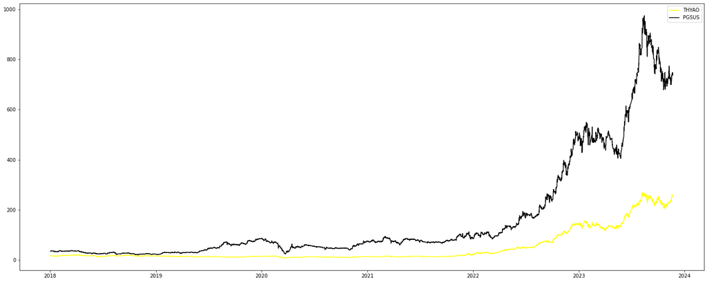

```python
# we firstly observe the data we possess, and we see that both stock prices shows a horizontal trend till mid 2022 and have
# a surge starting from mid 2022 and more volatile price changes are observed in both stocks, especially in PGSUS
# We can claim that by training the data until mid 2022, we can predict the rest of 2022 and 2023 more accurately, where the
# price fluctuations can create buy opportunities unlike the stagnant market until 2022.

plt.figure(figsize=(25, 10))
plt.plot(selected_stocks["date"], selected_stocks[stock1], label=stock1, color="yellow", )
plt.plot(selected_stocks["date"], selected_stocks[stock2], label=stock2, color="black")
plt.legend()
plt.show()
```

```python
print(selected_stocks.iloc[4963])
print(selected_stocks.iloc[12444])
```

```
date     2020-01-02 09:00:00
THYAO                   14.5
PGSUS                   86.5
Name: 4963, dtype: object
date     2023-01-02 09:00:00
THYAO                  142.4
PGSUS                  484.2
Name: 12444, dtype: object
```

```python
# Let's start with [2020-2022] period for training and 2023 for test

# Split the data into the train and test datasets for the linear regression
stock_1_train = selected_stocks[stock1][4963:12444]
stock_2_train = selected_stocks[stock2][4963:12444]
stock_1_test = selected_stocks[stock1][12444:]
stock_2_test = selected_stocks[stock2][12444:]
```

```python
# Create the linear regression model and determine the linear regression coefficients
# in this model, our target variable is stock 2 (PGSUS) according to the prices of stock 1(THYAO).
slope, intercept, r_value, p_value, std_err = linregress(stock_1_train, stock_2_train)

# Print the regression parameters
print(f'Linear Regression: Slope={slope}, Intercept={intercept}, R-squared={r_value**2}')

# Calculate Residuals
predictions_stock1 = intercept + slope * stock_1_test
residuals_stock1 = stock_2_test - (intercept + slope * stock_1_test)

# Print the first few residuals
print('Residuals:')
print(residuals_stock1.head())
```

```
Linear Regression: Slope=3.0365700820644723, Intercept=24.21629065513558, R-squared=0.9805413929063561
Residuals:
12444    27.576130
12445    27.124932
12446    27.521275
12447    28.824932
12448    31.202989
dtype: float64
```

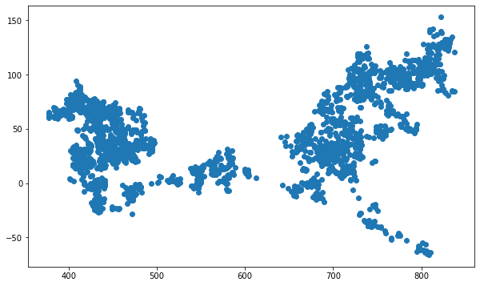

```python
# Before setting up the control chart, we can check if the constant variance assumption holds for the predictions we do on
# the test dataset by simply plotting the predictions on the x axis and residuals on the y axis.
# We observed that the the scatter plot below do not fit the constant variance assumption as the residuals appear
# to fan out as the predictions increase, indicating that the variance of residuals is increasing with the predicted values.

plt.figure(figsize=(10, 6))
plt.scatter(predictions_stock1, residuals_stock1)
```

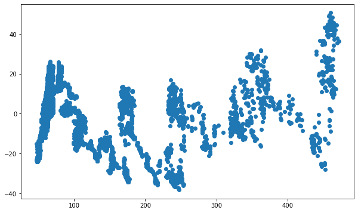

```python
# Before setting up the control chart, we also check if the constant variance assumption holds for the predictions we do on
# the train dataset by simply plotting the predictions on the x axis and residuals on the y axis.
# We observed that the the scatter plot below also do not fit the constant variance assumption as the residuals appear
# to fan out as the predictions increase, indicating that the variance of residuals is increasing with the predicted values.

residuals_train = stock_2_train - (intercept + slope * stock_1_train)
predictions_train = intercept + slope * stock_1_train

plt.figure(figsize=(10, 6))
plt.scatter(predictions_train, residuals_train)
```

[output not shown]

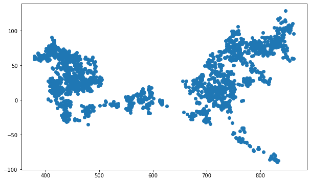

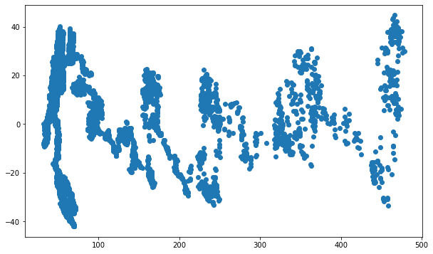

```python
# Now, try [-2022] period for training and 2023 for test

# Split the data into the train and test datasets for the linear regression
stock_1_train = selected_stocks[stock1][:12444]
stock_2_train = selected_stocks[stock2][:12444]
stock_1_test = selected_stocks[stock1][12444:]
stock_2_test = selected_stocks[stock2][12444:]
# Create the linear regression model and determine the linear regression coefficients
# in this model, our target variable is stock 2 (PGSUS) according to the prices of stock 1(THYAO).
slope, intercept, r_value, p_value, std_err = linregress(stock_1_train, stock_2_train)

# Print the regression parameters
print(f'Linear Regression: Slope={slope}, Intercept={intercept}, R-squared={r_value**2}')

# Calculate Residuals
predictions_stock1 = intercept + slope * stock_1_test
residuals_stock1 = stock_2_test - (intercept + slope * stock_1_test)

# Print the first few residuals
print('Residuals:')
print(residuals_stock1.head())

plt.figure(figsize=(10, 6))
plt.scatter(predictions_stock1, residuals_stock1)

residuals_train = stock_2_train - (intercept + slope * stock_1_train)
predictions_train = intercept + slope * stock_1_train

plt.figure(figsize=(10, 6))
plt.scatter(predictions_train, residuals_train)
```

```python
# Set up Control Chart
mean_residuals_stock1 = residuals_stock1.mean()
std_residuals_stock1 = residuals_stock1.std()

# Utilized 2 sigma instead of conventional 3 sigma limits as when 3 sigma is used, there are almost no outliers observed, which
# hinders trading simulation.

control_limits_upper_stock1 = mean_residuals_stock1 + 2 * std_residuals_stock1
control_limits_lower_stock1 = mean_residuals_stock1 - 2 * std_residuals_stock1
```

```python
index_temp = residuals_stock1.index
residuals_stock1.index = selected_stocks["date"][12444:]
```

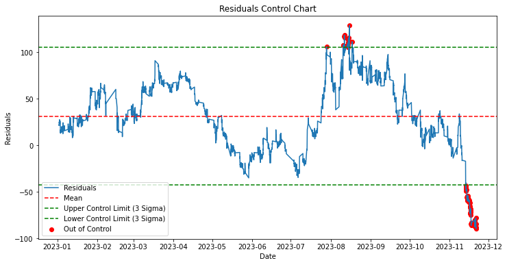

```python
# Plot Control Chart
plt.figure(figsize=(12, 6))
plt.plot(residuals_stock1.index, residuals_stock1, label='Residuals')
plt.axhline(y=mean_residuals_stock1, color='r', linestyle='--', label='Mean')
plt.axhline(y=control_limits_upper_stock1, color='g', linestyle='--', label='Upper Control Limit (3 Sigma)')
plt.axhline(y=control_limits_lower_stock1, color='g', linestyle='--', label='Lower Control Limit (3 Sigma)')

# Highlight points beyond the control limits
out_of_control_stock1 = residuals_stock1[(residuals_stock1 > control_limits_upper_stock1) | (residuals_stock1 < control_limits_lower_stock1)]
plt.scatter(out_of_control_stock1.index, out_of_control_stock1, color='red', label='Out of Control')

plt.title('Residuals Control Chart')
plt.xlabel('Date')
plt.ylabel('Residuals')
plt.legend()
plt.show()
```

```python
residuals_stock1.index = index_temp
```

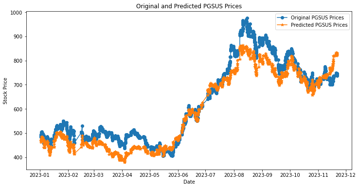

```python
# Plot Original and Predicted Stock Prices
plt.figure(figsize=(12, 6))

# Plot Original Stock Prices
plt.plot(selected_stocks[12444:]["date"], stock_2_test, label=f'Original {stock2} Prices', marker='o')

# Plot Predicted Stock Prices
plt.plot(selected_stocks[12444:]["date"], predictions_stock1, label=f'Predicted {stock2} Prices', marker='*')

plt.title(f'Original and Predicted {stock2} Prices')
plt.xlabel('Date')
plt.ylabel('Stock Price')
plt.legend()
plt.show()

# We observed the predicted and real test values together to observe whether the outliers really occur at the points that the
# expected and real values are differing.
```

```python
# Repeating the same steps for predicting THYAO prices by using PGSUS prices.

slope_stock2, intercept_stock2, r_value_stock2, p_value_stock2, std_err_stock2 = linregress(stock_2_train, stock_1_train)

# Print the regression parameters for Stock 2
print(f'Linear Regression for {stock2}: Slope={slope_stock2}, Intercept={intercept_stock2}, R-squared={r_value_stock2**2}')

# Calculate Residuals for Stock 2
residuals_stock2 = stock_1_test - (intercept_stock2 + slope_stock2 * stock_2_test)

# Step 5: Create DataFrame with Date, Stock Prices, Residuals, and Signals for Stock 1 and Stock 2
mean_residuals_stock2 = residuals_stock2.mean()
std_residuals_stock2 = residuals_stock2.std()
```

```
Linear Regression for PGSUS: Slope=0.2903945336664079, Intercept=-0.5730426399645836, R-squared=0.9266854762834864
```

```python
# Defined the conditions algorithm for signals for Stock 1 predictions,
conditions_stock1 = [
    (residuals_stock1 > mean_residuals_stock1 + 2 * std_residuals_stock1),
    (residuals_stock1 < mean_residuals_stock1 - 2 * std_residuals_stock1),
    ((residuals_stock1 >= mean_residuals_stock1 - 0.5*std_residuals_stock1) & (residuals_stock1 <= mean_residuals_stock1 + 0.5*std_residuals_stock1))
]

# Define corresponding values for the conditions for Stock 1
values_stock1 = ['larger than 3 sigma', 'smaller than 3 sigma', 'Terminate']

# Define the conditions for signals for Stock 2
conditions_stock2 = [
    (residuals_stock2 > mean_residuals_stock2 + 2 * std_residuals_stock2),
    (residuals_stock2 < mean_residuals_stock2 - 2 * std_residuals_stock2),
    ((residuals_stock2 >= mean_residuals_stock2 - 0.5*std_residuals_stock2) & (residuals_stock2 <= mean_residuals_stock2 + 0.5*std_residuals_stock2))
]

# Define corresponding values for the conditions for Stock 2
values_stock2 = ['larger than 3 sigma', 'smaller than 3 sigma', 'Terminate']
```

```python
# Create DataFrame for Stock 1
residuals_df_stock1 = pd.DataFrame({
    'date': selected_stocks[12444:]['date'],
    f'{stock1}_Price': stock_1_test,
    f'{stock2}_Price': stock_2_test,
    'Residual_Stock1': residuals_stock1,
    'Signal_Stock1': np.select(conditions_stock1, values_stock1, default='No Signal')
})

# Create DataFrame for Stock 2
residuals_df_stock2 = pd.DataFrame({
    'date': selected_stocks[12444:]['date'],
    'Residual_Stock2': residuals_stock2,
    'Signal_Stock2': np.select(conditions_stock2, values_stock2, default='No Signal')
})

# Merge the two DataFrames on 'Date'
residuals_df = pd.merge(residuals_df_stock1, residuals_df_stock2, on='date')

# Print the final DataFrame

residuals_df.to_excel("Simulation-THYAO-PGSUS.xlsx", sheet_name="THYAO-PGSUS", index=False)
```

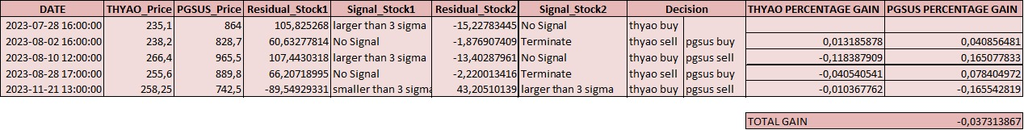

For this pair, there seems to be a 3% loss. In fact, it turned out like this because the assumption was made to apply a final operation in the last step. The essential operations were completed in the previous step and thus a profit of 13% was obtained.

## YKBNK - KCHOL PAIR

```python
# Let's select by the YKBNK KCHOL pair.
stock1 = 'YKBNK'
stock2 = 'KCHOL'

# Extract data for the selected stocks
selected_stocks = stock_data[["date", stock1, stock2]].dropna()

# Calculate Correlation coefficient of the pair of stocks again via a different library and print it.
correlation_coefficient, _ = pearsonr(selected_stocks[stock1], selected_stocks[stock2])
print(f'Correlation Coefficient between {stock1} and {stock2}: {correlation_coefficient}')
```

```
Correlation Coefficient between YKBNK and KCHOL: 0.9894054686584351
```

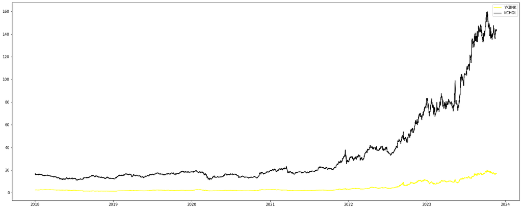

```python
# we firstly observe the data we possess, and we see that both stock prices shows a horizontal trend till mid 2022 and have
# a surge starting from mid 2022 and more volatile price changes are observed in both stocks, especially in KCHOL
# We can claim that by training the data until mid 2022, we can predict the rest of 2022 and 2023 more accurately, where the
# price fluctuations can create buy opportunities unlike the stagnant market until 2022.

plt.figure(figsize=(25, 10))
plt.plot(selected_stocks["date"], selected_stocks[stock1], label=stock1, color="yellow", )
plt.plot(selected_stocks["date"], selected_stocks[stock2], label=stock2, color="black")
plt.legend()
plt.show()
```

```python
# Let's start with [2020-2022] period for training and 2023 for test

# Split the data into the train and test datasets for the linear regression
stock_1_train = selected_stocks[stock1][4963:12444]
stock_2_train = selected_stocks[stock2][4963:12444]
stock_1_test = selected_stocks[stock1][12444:]
stock_2_test = selected_stocks[stock2][12444:]
```

```python
# Create the linear regression model and determine the linear regression coefficients
# in this model, our target variable is stock 2 (KCHOL) according to the prices of stock 1(YKBNK).
slope, intercept, r_value, p_value, std_err = linregress(stock_1_train, stock_2_train)

# Print the regression parameters
print(f'Linear Regression: Slope={slope}, Intercept={intercept}, R-squared={r_value**2}')

# Calculate Residuals
predictions_stock1 = intercept + slope * stock_1_test
residuals_stock1 = stock_2_test - (intercept + slope * stock_1_test)

# Print the first few residuals
print('Residuals:')
print(residuals_stock1.head())
```

```
Linear Regression: Slope=6.296062917692889, Intercept=5.541953818504343, R-squared=0.9367450034720758
Residuals:
12444    8.415634
12445    7.783918
12446    7.664716
12447    7.540475
12448    7.442675
dtype: float64
```

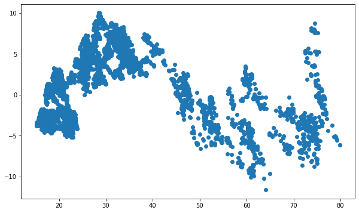

```python
# Before setting up the control chart, we also check if the constant variance assumption holds for the predictions we do on
# the train dataset by simply plotting the predictions on the x axis and residuals on the y axis.
# We observed that the the scatter plot below also approximately fits the constant variance assumption as the residuals appear
# to not fan out as the predictions increase, indicating that variance of residuals is almost constant with predicted values.

residuals_train = stock_2_train - (intercept + slope * stock_1_train)
predictions_train = intercept + slope * stock_1_train

plt.figure(figsize=(10, 6))
plt.scatter(predictions_train, residuals_train)
```

[output not shown]

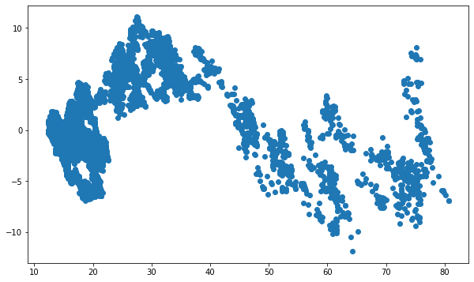

```python
# Now also try [-2022] period for training and 2023 for test

# Split the data into the train and test datasets for the linear regression
stock_1_train = selected_stocks[stock1][:12444]
stock_2_train = selected_stocks[stock2][:12444]
stock_1_test = selected_stocks[stock1][12444:]
stock_2_test = selected_stocks[stock2][12444:]
# Create the linear regression model and determine the linear regression coefficients
# in this model, our target variable is stock 2 (KCHOL) according to the prices of stock 1(YKBNK).
slope, intercept, r_value, p_value, std_err = linregress(stock_1_train, stock_2_train)

# Print the regression parameters
print(f'Linear Regression: Slope={slope}, Intercept={intercept}, R-squared={r_value**2}')

residuals_train = stock_2_train - (intercept + slope * stock_1_train)
predictions_train = intercept + slope * stock_1_train

plt.figure(figsize=(10, 6))
plt.scatter(predictions_train, residuals_train)
```

```python
# Set up Control Chart
mean_residuals_stock1 = residuals_stock1.mean()
std_residuals_stock1 = residuals_stock1.std()

control_limits_upper_stock1 = mean_residuals_stock1 + 2 * std_residuals_stock1
control_limits_lower_stock1 = mean_residuals_stock1 - 2 * std_residuals_stock1
```

```python
index_temp = residuals_stock1.index
residuals_stock1.index = selected_stocks["date"][12444:]
```

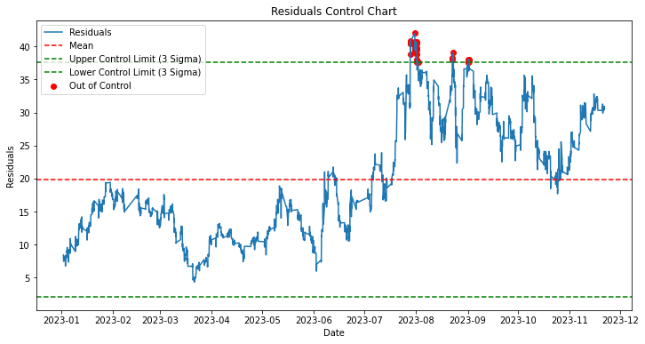

```python
# Plot Control Chart
plt.figure(figsize=(12, 6))
plt.plot(residuals_stock1.index, residuals_stock1, label='Residuals')
plt.axhline(y=mean_residuals_stock1, color='r', linestyle='--', label='Mean')
plt.axhline(y=control_limits_upper_stock1, color='g', linestyle='--', label='Upper Control Limit (3 Sigma)')
plt.axhline(y=control_limits_lower_stock1, color='g', linestyle='--', label='Lower Control Limit (3 Sigma)')

# Highlight points beyond the control limits
out_of_control_stock1 = residuals_stock1[(residuals_stock1 > control_limits_upper_stock1) | (residuals_stock1 < control_limits_lower_stock1)]
plt.scatter(out_of_control_stock1.index, out_of_control_stock1, color='red', label='Out of Control')

plt.title('Residuals Control Chart')
plt.xlabel('Date')
plt.ylabel('Residuals')
plt.legend()
plt.show()
```

```python
residuals_stock1.index = index_temp
```

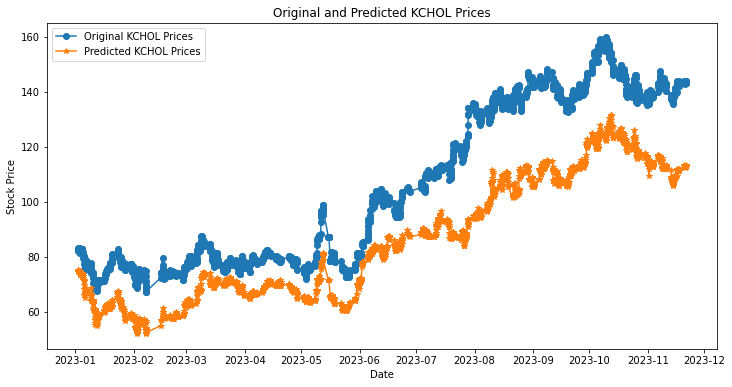

```python
# Plot Original and Predicted Stock Prices
plt.figure(figsize=(12, 6))

# Plot Original Stock Prices
plt.plot(selected_stocks[12444:]["date"], stock_2_test, label=f'Original {stock2} Prices', marker='o')

# Plot Predicted Stock Prices
plt.plot(selected_stocks[12444:]["date"], predictions_stock1, label=f'Predicted {stock2} Prices', marker='*')

plt.title(f'Original and Predicted {stock2} Prices')
plt.xlabel('Date')
plt.ylabel('Stock Price')
plt.legend()
plt.show()
```

```python
slope_stock2, intercept_stock2, r_value_stock2, p_value_stock2, std_err_stock2 = linregress(stock_2_train, stock_1_train)

# Print the regression parameters for Stock 2
print(f'Linear Regression for {stock2}: Slope={slope_stock2}, Intercept={intercept_stock2}, R-squared={r_value_stock2**2}')

# Calculate Residuals for Stock 2
residuals_stock2 = stock_1_test - (intercept_stock2 + slope_stock2 * stock_2_test)

# Step 5: Create DataFrame with Date, Stock Prices, Residuals, and Signals for Stock 1 and Stock 2
mean_residuals_stock2 = residuals_stock2.mean()
std_residuals_stock2 = residuals_stock2.std()
```

```
Linear Regression for KCHOL: Slope=0.14137551140295568, Intercept=-0.29372857643187755, R-squared=0.9227305435069953
```

```python
# Define the conditions for signals for Stock 1
conditions_stock1 = [
    (residuals_stock1 > mean_residuals_stock1 + 2 * std_residuals_stock1),
    (residuals_stock1 < mean_residuals_stock1 - 2 * std_residuals_stock1),
    ((residuals_stock1 >= mean_residuals_stock1 - 0.5*std_residuals_stock1) & (residuals_stock1 <= mean_residuals_stock1 + 0.5*std_residuals_stock1))
]

# Define corresponding values for the conditions for Stock 1
values_stock1 = ['larger than 3 sigma', 'smaller than 3 sigma', 'Terminate']

# Define the conditions for signals for Stock 2
conditions_stock2 = [
    (residuals_stock2 > mean_residuals_stock2 + 2 * std_residuals_stock2),
    (residuals_stock2 < mean_residuals_stock2 - 2 * std_residuals_stock2),
    ((residuals_stock2 >= mean_residuals_stock2 - 0.5*std_residuals_stock2) & (residuals_stock2 <= mean_residuals_stock2 + 0.5*std_residuals_stock2))
]

# Define corresponding values for the conditions for Stock 2
values_stock2 = ['larger than 3 sigma', 'smaller than 3 sigma', 'Terminate']
```

```python
# Create DataFrame for Stock 1
residuals_df_stock1 = pd.DataFrame({
    'date': selected_stocks[12444:]['date'],
    f'{stock1}_Price': stock_1_test,
    f'{stock2}_Price': stock_2_test,
    'Residual_Stock1': residuals_stock1,
    'Signal_Stock1': np.select(conditions_stock1, values_stock1, default='No Signal')
})

# Create DataFrame for Stock 2
residuals_df_stock2 = pd.DataFrame({
    'date': selected_stocks[12444:]['date'],
    'Residual_Stock2': residuals_stock2,
    'Signal_Stock2': np.select(conditions_stock2, values_stock2, default='No Signal')
})

# Merge the two DataFrames on 'Date'
residuals_df = pd.merge(residuals_df_stock1, residuals_df_stock2, on='date')

# Print the final DataFrame

residuals_df.to_excel("Simulation-YKBNK-KCHOL.xlsx", sheet_name="YKBNK-KCHOL", index=False)
```

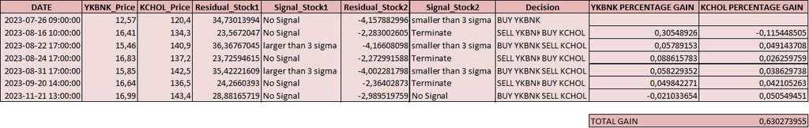

The cumulative percentage gain after buying and selling transactions was determined as 63%. This is a very successful result for such a trading transaction.

### Task 2: Advanced Pairs Trading Strategy Using Time Series Analysis

```python
stock1 = 'THYAO'
stock2 = 'PGSUS'

selected_stocks = stock_data[["date", stock1, stock2]].dropna()

correlation_coefficient, _ = pearsonr(selected_stocks[stock1], selected_stocks[stock2])
print(f'Correlation Coefficient between {stock1} and {stock2}: {correlation_coefficient}')

stock_1_train = selected_stocks[stock1][10000:12444]
stock_2_train = selected_stocks[stock2][10000:12444]
stock_1_test = selected_stocks[stock1][12444:]
stock_2_test = selected_stocks[stock2][12444:]

slope, intercept, r_value, p_value, std_err = linregress(stock_1_train, stock_2_train)

print(f'Linear Regression: Slope={slope}, Intercept={intercept}, R-squared={r_value**2}')

# Calculate Residuals
predictions_stock1 = intercept + slope * stock_1_train
residuals_stock1 = stock_2_train - (intercept + slope * stock_1_train)
```

```
Correlation Coefficient between THYAO and PGSUS: 0.9930375730033902
Linear Regression: Slope=3.2714442580418392, Intercept=2.975887854775465, R-squared=0.9859189466050727
```

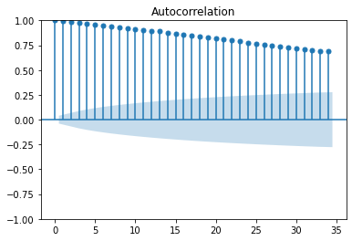

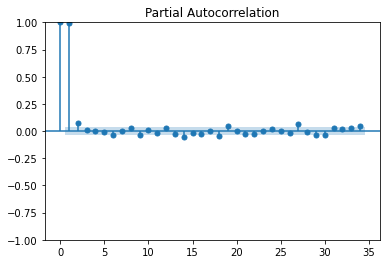

```
Performing stepwise search to minimize aic
 ARIMA(2,1,2)(0,0,0)[0] intercept   : AIC=10001.426, Time=0.59 sec
 ARIMA(0,1,0)(0,0,0)[0] intercept   : AIC=10009.230, Time=0.05 sec
 ARIMA(1,1,0)(0,0,0)[0] intercept   : AIC=9995.836, Time=0.13 sec
 ARIMA(0,1,1)(0,0,0)[0] intercept   : AIC=9995.559, Time=0.16 sec
 ARIMA(0,1,0)(0,0,0)[0]             : AIC=10007.230, Time=0.04 sec
 ARIMA(1,1,1)(0,0,0)[0] intercept   : AIC=9997.506, Time=0.64 sec
 ARIMA(0,1,2)(0,0,0)[0] intercept   : AIC=9997.496, Time=0.21 sec
 ARIMA(1,1,2)(0,0,0)[0] intercept   : AIC=9999.490, Time=0.28 sec
 ARIMA(0,1,1)(0,0,0)[0]             : AIC=9993.559, Time=0.07 sec
 ARIMA(1,1,1)(0,0,0)[0]             : AIC=9995.506, Time=0.17 sec
 ARIMA(0,1,2)(0,0,0)[0]             : AIC=9995.496, Time=0.09 sec
 ARIMA(1,1,0)(0,0,0)[0]             : AIC=9993.836, Time=0.06 sec
 ARIMA(1,1,2)(0,0,0)[0]             : AIC=9997.490, Time=0.14 sec

Best model:  ARIMA(0,1,1)(0,0,0)[0]
Total fit time: 2.630 seconds
 ARIMA(0,1,1)(0,0,0)[0]
                               SARIMAX Results
==============================================================================
Dep. Variable:                      y   No. Observations:                 2444
Model:                 ARIMA(0, 1, 1)   Log Likelihood               -4994.779
Date:                Mon, 11 Dec 2023   AIC                           9993.559
Time:                        23:41:01   BIC                          10005.161
Sample:                             0   HQIC                          9997.776
                               - 2444
Covariance Type:                  opg
==============================================================================
                 coef    std err          z      P>|z|      [0.025      0.975]
------------------------------------------------------------------------------
ma.L1         -0.0806      0.011     -7.045      0.000      -0.103      -0.058
sigma2         3.4944      0.038     92.540      0.000       3.420       3.568
===================================================================================
Ljung-Box (L1) (Q):                   0.00   Jarque-Bera (JB):             14828.99
Prob(Q):                              0.98   Prob(JB):                         0.00
Heteroskedasticity (H):              17.80   Skew:                             0.35
Prob(H) (two-sided):                  0.00   Kurtosis:                        15.05
===================================================================================

Warnings:
[1] Covariance matrix calculated using the outer product of gradients (complex-step).
```

```python
from pmdarima import auto_arima

plot_acf(residuals_stock1)
plot_pacf(residuals_stock1)
plt.show()

auto_model = auto_arima(residuals_stock1, suppress_warnings=True, trace=True)
print(auto_model)
order = auto_model.get_params()['order']

# Fit ARIMA model with the selected order
model = ARIMA(residuals_stock1, order=order)
results = model.fit()

# Get model summary
print(results.summary())
```

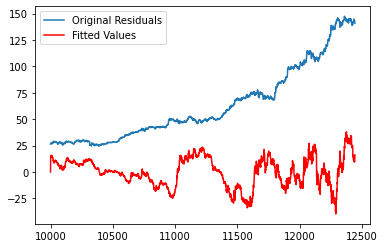

```python
plt.plot(stock_1_train, label='Original Residuals')
plt.plot(results.fittedvalues, color='red', label='Fitted Values')
plt.legend()
plt.show()
 # Define the number of steps to forecast into the future (adjust as needed)
forecast_steps = len(stock_1_test)  # for example, forecasting 12 months

# Get the forecast and confidence intervals
forecast_results = results.get_forecast(steps=forecast_steps)
forecast = forecast_results.predicted_mean
conf_int = forecast_results.conf_int()
```

### Conclusion

The pairs trading strategy was used in the transactions. It was examined whether it was appropriate to use highly correlated stock pairs. The results obtained from the evaluated couples showed that successful results can be achieved with this strategy. One pair made a 63% profit while the other made a 13% profit. While performing these operations, a linear regression model was used and the constant variance assumption was used. A trading simulation based on control charts was made and the desired result was achieved. The topic addressed during the simulation period was the signals given by the pairs. The observed signals contributed to the correct trades and the successful operation of the simulation. The damage observed in the THYAO-PGSUS pair does not reflect the facts. According to the project assumptions, another move was made in the last step, but it is seen that if the previous step was left, a 13% profit would have been achieved.